# L5P1-Exercício 2

```r
dados_raw = read_csv(
    here::here("data/participation-per-country.csv"),
    col_types = cols(
        .default = col_double(),
        site = col_character(),
        country = col_character(),
        geo = col_character(),
        four_regions = col_character(),
        eight_regions = col_character(),
        six_regions = col_character(),
        `World bank income group 2017` = col_character()
    )
) %>% janitor::clean_names()


dados = dados_raw %>%
    filter(site == "StackOverflow" || site == "SuperUser")

glimpse(dados)
```

```
## Rows: 157
## Columns: 21
## $ site                         <chr> "StackOverflow", "StackOverflow", "StackO~
## $ country                      <chr> "Argentina", "Australia", "Austria", "Ban~
## $ pdi                          <dbl> 49, 36, 11, 80, 65, 69, 70, 39, 63, 80, 6~
## $ idv                          <dbl> 46, 90, 55, 20, 75, 38, 30, 80, 23, 20, 1~
## $ mas                          <dbl> 56, 61, 79, 55, 54, 49, 40, 52, 28, 66, 6~
## $ uai                          <dbl> 86, 51, 70, 60, 94, 76, 85, 48, 86, 30, 8~
## $ usuarios                     <dbl> 2798, 12313, 2518, 2558, 4275, 10717, 146~
## $ responderam_prop             <dbl> 0.5357398, 0.6133355, 0.6310564, 0.392885~
## $ perguntaram_prop             <dbl> 0.5210865, 0.5897832, 0.5933280, 0.475762~
## $ editaram_prop                <dbl> 0.09256612, 0.14699911, 0.14932486, 0.080~
## $ comentaram_prop              <dbl> 0.25339528, 0.33395598, 0.35027800, 0.159~
## $ gni                          <dbl> NA, 59570, 48160, 840, 44990, 11630, 6870~
## $ internet                     <dbl> 51.0, 79.5, 79.8, 5.0, 78.0, 45.0, 51.0, ~
## $ epi                          <dbl> 59.02, NA, 63.21, NA, 61.21, 49.96, NA, N~
## $ geo                          <chr> "arg", "aus", "aut", "bgd", "bel", "bra",~
## $ four_regions                 <chr> "americas", "asia", "europe", "asia", "eu~
## $ eight_regions                <chr> "america_south", "east_asia_pacific", "eu~
## $ six_regions                  <chr> "america", "east_asia_pacific", "europe_c~
## $ latitude                     <dbl> -34.00000, -25.00000, 47.33333, 24.00000,~
## $ longitude                    <dbl> -64.00000, 135.00000, 13.33333, 90.00000,~
## $ world_bank_income_group_2017 <chr> "Upper middle income", "High income", "Hi~
```

```r
relacao_dados_SuperUser = dados %>%
    filter (is.na(epi) == FALSE, site == "SuperUser") %>%
    select(site, epi, responderam_prop)
```

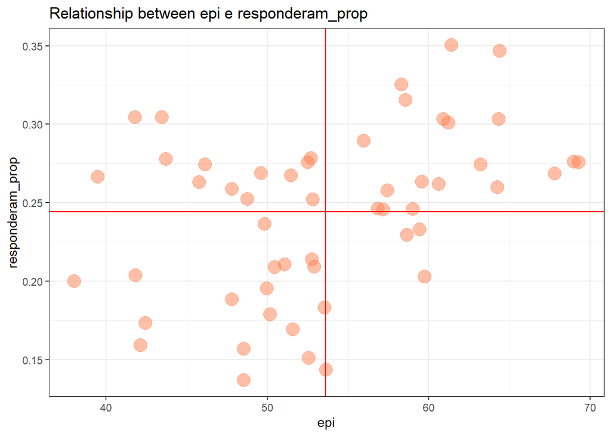

```r
relacao_dados_SuperUser %>%

ggplot(aes(x = epi, y = responderam_prop)) +
  geom_point(size = 5, alpha = .5, color = "coral") +
  geom_hline(yintercept = mean(relacao_dados_SuperUser$responderam_prop), color = "red") +
  geom_vline(xintercept = mean(relacao_dados_SuperUser$epi), color = "red") +


  labs(x = "epi", y = "responderam_prop",
       title = "Relationship between epi e responderam_prop")
```

O gráfico de dispersão mostra comportamentos das variáveis respoderam_prop e EPI na amostra SuperUser. Considera-se respoderam_prop como variável dependente e EPI como variáveil independente. O gráfico de dispersão mostra uma possível relação positiva entre essas variáveis por visualizar que seus pontos amostrais indicam uma reta positivamente inclinada, porém com bastante disperção dos pontos amostrais. Também, é possível que a melhor função matemática que descreva a relação entre essas duas variáveis possa não ser um modelo linear. Inicialmente, estima-se um modelo linear com as variáveis em nível, ou seja, com seus valores originais. Em seguida, estima-se um modelo transformando as variáveis (dependente e independete) em logarítimo para linearizar essa relação.